# Ejecutando Scripts de Python

## Clonar el repositorio

Desde Github vamos a clonar un reposiotio creado para los scripts o codigos del curso.

Rutas de repositorios

- https://github.com/Juanklg/G29-MinTic.git
- https://github.com/Juanklg/Mintic-G48.git
- https://github.com/Juanklg/G61-MinTic.git

Para clonar un repositorio nos ubicamos en el terminal de visula stuido code

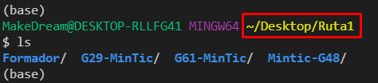

Una vez ubicados en la ruta donde se va a descargarla carpeta ejecutamos el comando

#### git clone xxxxxxx

remplazamos por el respectivo link del grupo

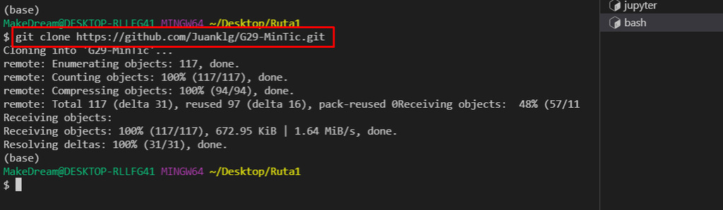

Esperamos aque se complete la descarga y verificamos que la carpeta se agregre a nuestro espacio de trabajo

## Abrir la carpeta de scripts en la terminal

Ubicamos la carpeta en el panel izquierdo y damos click derecho y seleccionamos la opcion n°4 -Open in integrate terminal o Abrir en terminal integrado

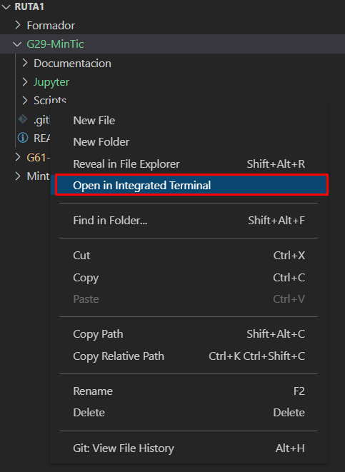

## Ejecutar un Script de la carpeta de apoyo

Manejamos 2 carpetas con la informacion que hemos trabajado

- Actividades : Tenemos los ejercicios que realizamos en clase
- ParaDoc : En esta tenemos los scripts q vamos a documentar en jupyter notebook

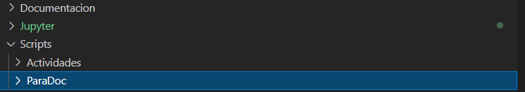

Para ejercutar un script tenemos 2 opciones

1- ingresar a la carpeta con el comando "cd", un espacio y el nombre de la carpeta, le damos el comando "ls" y observamos la lista de ejercicios q podemos ejecuatar

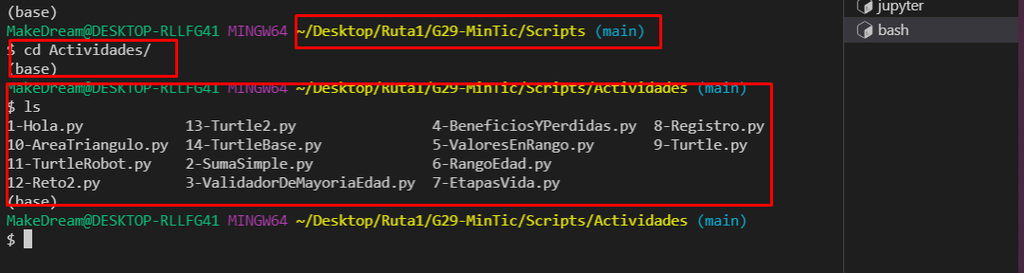

despues ejecutamos el comando "python", un espacio y el nombre del archivo que vamos a ejecutar

2- desde la ruta de scripts ejecutar el script teniendo en cuenta la ruta del archivo dentro de la carpeta respectiva

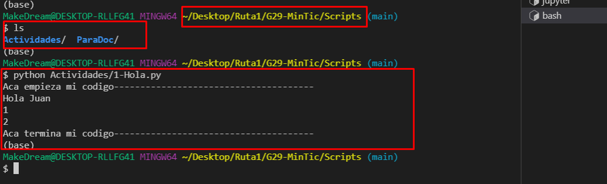

## Actualizando la carpeta del grupo

Para estar al dia con los ultimos cambios de la carpeta del grupo debemos ir a la carpeta del grupo en el terminal

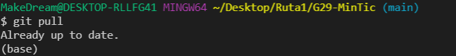

despues vamos a la terminal y ejecutamos el siguiente comando

#### git pull

Esto descargara lña ultima version de la carpeta disponible

##### Nota

Recuerde que no debe modificar ninguno de los archivos de esta carpeta. Si lo hace no podra descargar la ultima version de la misma.

En caso de modificarlos por accidente borre la carpeta y repita el proceso de clonar el repositorio